# Peer Review 1

Secular

Sunday, July 19, 2015

I will be presenting the first Peer Evaluation for the Reproducible Research course from John’s Hopkins University.

First it will read in the contents of the of the Activity.csv file. Which will be which will be followed by several data cleanup steps to prepare the data for analysis

- Conevrt the interval variable to “minutes from midnight”
- Convert dates to standard dates
- Next create a new dataframe which is corrected for NAs.  
  ** In order to do that we first determine average or mean steps taken in each time interval using the data present to the closest integer.  
  ** Then generate a copy of the original dataframe NAs are repaced by the average steps for the corresponing interval  
  ** Also append a new column to the dataframe to which shows if the date is a weekday (= TRUE), or weekend day (= FALSE)
- Next the original data frame is split by dates and the stats (median, Mean, & total) of activity for each day will be computed
- The stats for the activity data with the NAs filled is then computed, as in the above step
- The activity data with NAs filled in is split into weekday & weekend data frames

```r
library(timeDate)
```

```r
library(graphics)
activity <- read.csv("activity.csv")

#  Converting interval into minutes from midnight
activity$minsFromMidnight <- activity$interval%%100 + + as.integer(activity$interval/100)*60

#   Converting the date into standard date format
activity$date = as.factor(as.Date(as.character(activity$date), "%m/%d/%Y"))

#   Duplicating the data with the NAs substituted with the average for the corresponding interval
activitySansNAs <-  activity
activitySansNAsSplitbyInterval <- split(activitySansNAs, activitySansNAs$interval)

#   Computed the average steps for each interval
meanByInterval <- sapply(activitySansNAsSplitbyInterval, function(x){mean = floor(mean(x$steps,na.rm = TRUE) + 0.5)})

#   Replacing NAs
for(n in 1:nrow(activitySansNAs)){ if (is.na(activitySansNAs[n, "steps"])){ activitySansNAs[n, "steps"] <- meanByInterval[as.character(activitySansNAs[n,"interval"])]}}

#   Determining the weekday/weekend day from the date
activitySansNAs$isItWeekday <- isWeekday(activitySansNAs$date)
```

# Start of Computations for presentation

## What is mean total number of steps taken per day?

```r
#   Splitting the original data by date and then computing the statistics
activityByDay <- split(activity, activity$date)
statsActivityByDate <- sapply(activityByDay, function(x){
  c(median = median(x$steps, na.rm = TRUE),
    mean = mean(x$steps, na.rm = TRUE),
    total = sum(x$steps, na.rm  = TRUE))
})


#   Transposing the matrix
statsActivityByDate <- t(statsActivityByDate)
class(statsActivityByDate)
```

```
## [1] "matrix"
```

```r
colnames(statsActivityByDate)
```

```
## [1] "median" "mean"   "total"
```

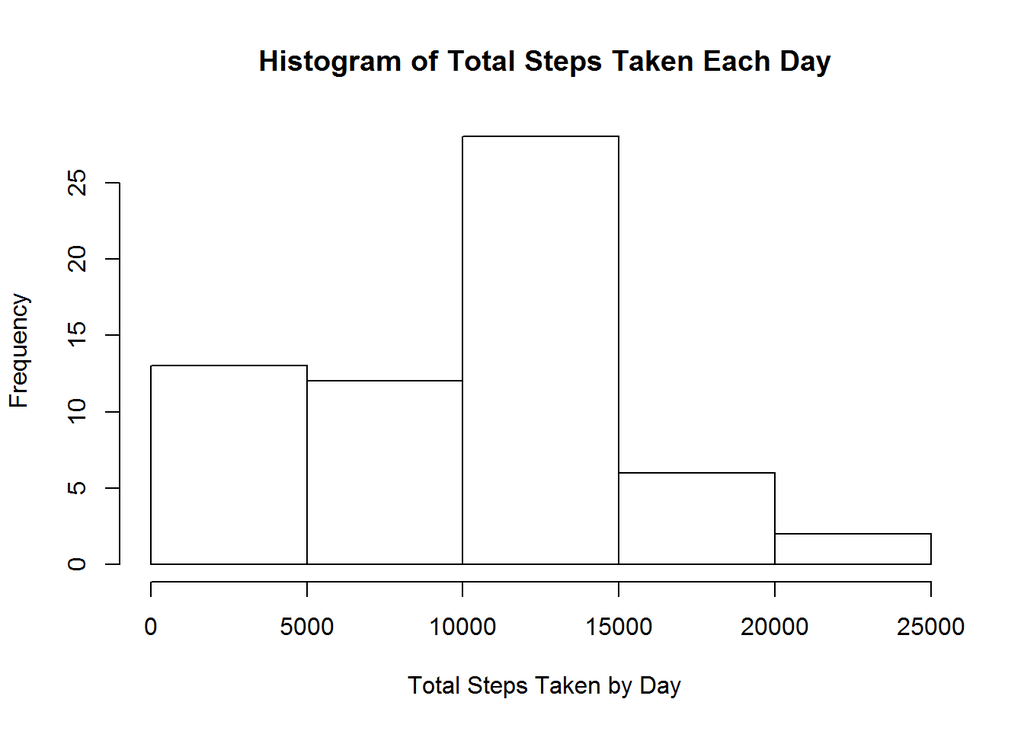

```r
hist(statsActivityByDate[ , 3], xlab = " Total Steps Taken by Day", main = " Histogram of Total Steps Taken Each Day")
```

```r
statsActivityByDate
```

```
##            median       mean total
## 2012-10-01     NA        NaN     0
## 2012-10-02      0  0.4375000   126
## 2012-10-03      0 39.4166667 11352
## 2012-10-04      0 42.0694444 12116
## 2012-10-05      0 46.1597222 13294
## 2012-10-06      0 53.5416667 15420
## 2012-10-07      0 38.2465278 11015
## 2012-10-08     NA        NaN     0
## 2012-10-09      0 44.4826389 12811
## 2012-10-10      0 34.3750000  9900
## 2012-10-11      0 35.7777778 10304
## 2012-10-12      0 60.3541667 17382
## 2012-10-13      0 43.1458333 12426
## 2012-10-14      0 52.4236111 15098
## 2012-10-15      0 35.2048611 10139
## 2012-10-16      0 52.3750000 15084
## 2012-10-17      0 46.7083333 13452
## 2012-10-18      0 34.9166667 10056
## 2012-10-19      0 41.0729167 11829
## 2012-10-20      0 36.0937500 10395
## 2012-10-21      0 30.6284722  8821
## 2012-10-22      0 46.7361111 13460
## 2012-10-23      0 30.9652778  8918
## 2012-10-24      0 29.0104167  8355
## 2012-10-25      0  8.6527778  2492
## 2012-10-26      0 23.5347222  6778
## 2012-10-27      0 35.1354167 10119
## 2012-10-28      0 39.7847222 11458
## 2012-10-29      0 17.4236111  5018
## 2012-10-30      0 34.0937500  9819
## 2012-10-31      0 53.5208333 15414
## 2012-11-01     NA        NaN     0
## 2012-11-02      0 36.8055556 10600
## 2012-11-03      0 36.7048611 10571
## 2012-11-04     NA        NaN     0
## 2012-11-05      0 36.2465278 10439
## 2012-11-06      0 28.9375000  8334
## 2012-11-07      0 44.7326389 12883
## 2012-11-08      0 11.1770833  3219
## 2012-11-09     NA        NaN     0
## 2012-11-10     NA        NaN     0
## 2012-11-11      0 43.7777778 12608
## 2012-11-12      0 37.3784722 10765
## 2012-11-13      0 25.4722222  7336
## 2012-11-14     NA        NaN     0
## 2012-11-15      0  0.1423611    41
## 2012-11-16      0 18.8923611  5441
## 2012-11-17      0 49.7881944 14339
## 2012-11-18      0 52.4652778 15110
## 2012-11-19      0 30.6979167  8841
## 2012-11-20      0 15.5277778  4472
## 2012-11-21      0 44.3993056 12787
## 2012-11-22      0 70.9270833 20427
## 2012-11-23      0 73.5902778 21194
## 2012-11-24      0 50.2708333 14478
## 2012-11-25      0 41.0902778 11834
## 2012-11-26      0 38.7569444 11162
## 2012-11-27      0 47.3819444 13646
## 2012-11-28      0 35.3576389 10183
## 2012-11-29      0 24.4687500  7047
## 2012-11-30     NA        NaN     0
```

## What is the average daily activity pattern?

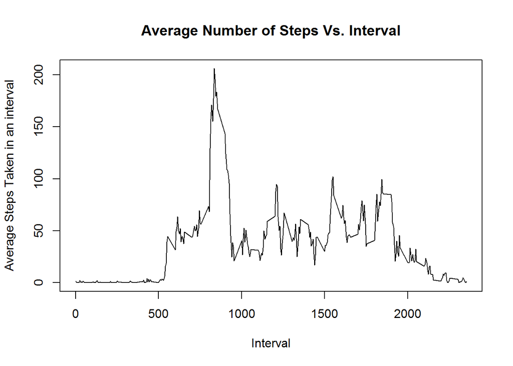

```r
#   Splitting the original by timeinterval
activityByInterval <- split(activity, activity$interval)
meansActivitybyInerval <- sapply(activityByInterval, function(x) {c(interval = x$interva[1], minsFromMidnight = x$minsFromMidnight[1], mean = mean(x$steps, na.rm = TRUE))})
meansActivitybyInerval <- t(meansActivitybyInerval)
meansActivitybyInerval <- as.data.frame(meansActivitybyInerval)
plot(meansActivitybyInerval$interval, meansActivitybyInerval$mea, type = "l", ylab = "Average Steps Taken in an interval", xlab = "Interval", main = "Average Number of Steps Vs. Interval")
```

## Plots reports with missing values imputed

One notices that the means do not change significantly at all. The median appears to skew where the originally data was not present. Else very little changes.

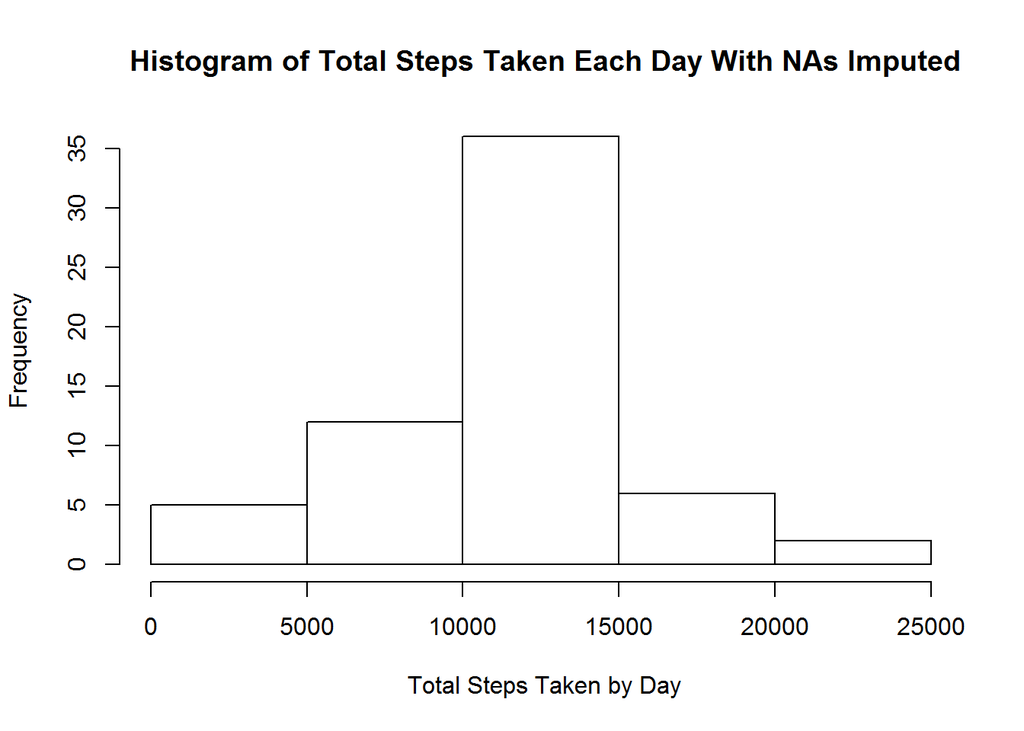

```r
#   Splitting the NAs filled data by date and then computing the statistics
activityByDaySansNAs <- split(activitySansNAs , activitySansNAs $date)
statsActivityBydateSansNAs  <- sapply(activityByDaySansNAs , function(x){
  c(median = median(x$steps, na.rm = TRUE),
    mean = mean(x$steps, na.rm = TRUE),
    total = sum(x$steps, na.rm = TRUE))
})
statsActivityBydateSansNAs  <- t(statsActivityBydateSansNAs )


hist(statsActivityBydateSansNAs[ , 3], xlab = " Total Steps Taken by Day", main = " Histogram of Total Steps Taken Each Day With NAs Imputed")
```

```r
statsActivityBydateSansNAs[ , 1:2]
```

```
##            median       mean
## 2012-10-01   34.5 37.3680556
## 2012-10-02    0.0  0.4375000
## 2012-10-03    0.0 39.4166667
## 2012-10-04    0.0 42.0694444
## 2012-10-05    0.0 46.1597222
## 2012-10-06    0.0 53.5416667
## 2012-10-07    0.0 38.2465278
## 2012-10-08   34.5 37.3680556
## 2012-10-09    0.0 44.4826389
## 2012-10-10    0.0 34.3750000
## 2012-10-11    0.0 35.7777778
## 2012-10-12    0.0 60.3541667
## 2012-10-13    0.0 43.1458333
## 2012-10-14    0.0 52.4236111
## 2012-10-15    0.0 35.2048611
## 2012-10-16    0.0 52.3750000
## 2012-10-17    0.0 46.7083333
## 2012-10-18    0.0 34.9166667
## 2012-10-19    0.0 41.0729167
## 2012-10-20    0.0 36.0937500
## 2012-10-21    0.0 30.6284722
## 2012-10-22    0.0 46.7361111
## 2012-10-23    0.0 30.9652778
## 2012-10-24    0.0 29.0104167
## 2012-10-25    0.0  8.6527778
## 2012-10-26    0.0 23.5347222
## 2012-10-27    0.0 35.1354167
## 2012-10-28    0.0 39.7847222
## 2012-10-29    0.0 17.4236111
## 2012-10-30    0.0 34.0937500
## 2012-10-31    0.0 53.5208333
## 2012-11-01   34.5 37.3680556
## 2012-11-02    0.0 36.8055556
## 2012-11-03    0.0 36.7048611
## 2012-11-04   34.5 37.3680556
## 2012-11-05    0.0 36.2465278
## 2012-11-06    0.0 28.9375000
## 2012-11-07    0.0 44.7326389
## 2012-11-08    0.0 11.1770833
## 2012-11-09   34.5 37.3680556
## 2012-11-10   34.5 37.3680556
## 2012-11-11    0.0 43.7777778
## 2012-11-12    0.0 37.3784722
## 2012-11-13    0.0 25.4722222
## 2012-11-14   34.5 37.3680556
## 2012-11-15    0.0  0.1423611
## 2012-11-16    0.0 18.8923611
## 2012-11-17    0.0 49.7881944
## 2012-11-18    0.0 52.4652778
## 2012-11-19    0.0 30.6979167
## 2012-11-20    0.0 15.5277778
## 2012-11-21    0.0 44.3993056
## 2012-11-22    0.0 70.9270833
## 2012-11-23    0.0 73.5902778
## 2012-11-24    0.0 50.2708333
## 2012-11-25    0.0 41.0902778
## 2012-11-26    0.0 38.7569444
## 2012-11-27    0.0 47.3819444
## 2012-11-28    0.0 35.3576389
## 2012-11-29    0.0 24.4687500
## 2012-11-30   34.5 37.3680556
```

## Are there differences in activity patterns between weekdays and weekends?

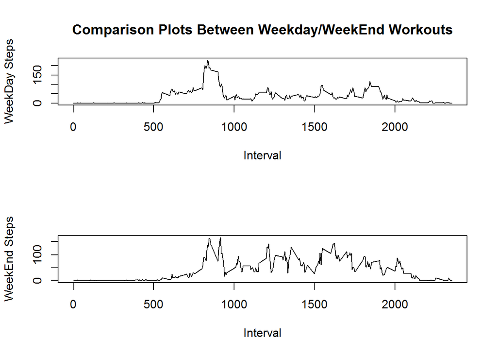

```r
#   Split the NAs filled in data frame by weekday & weekend days.
activitySansNAsByWeekdayWeekend <- split(activitySansNAs, activitySansNAs$isItWeekday)
names(activitySansNAsByWeekdayWeekend) <- c("WeekEnd","WeekDay")

#   Then computing the means for both the split data sub-sets per interval
activitySansNAsByForWeekend <- split(activitySansNAsByWeekdayWeekend[["WeekEnd"]], activitySansNAsByWeekdayWeekend[["WeekEnd"]]$interval)

activitySansNAsByForWeekday <- split(activitySansNAsByWeekdayWeekend[["WeekDay"]], activitySansNAsByWeekdayWeekend[["WeekDay"]]$interval)

weekendMeansByInterval <- sapply(activitySansNAsByForWeekend, function (x) { weekendMeans = mean(x$steps)})
weekdayMeansByInterval <- sapply(activitySansNAsByForWeekday, function (x) { weekendMeans = mean(x$steps)})



#   Cbind the various column to create amatix of means for week & weekend days
averageStepsByinterval <- cbind(unique(activitySansNAs$interval), unique(activitySansNAs$minsFromMidnight),
                               weekdayMeansByInterval, weekendMeansByInterval)
colnames(averageStepsByinterval)[1:2] <- c("interval", "minsFromMdinight")


old.par <- par(mfrow = c(2,1))
windows.options(width=10, height=10)

plot(averageStepsByinterval[ , 1], averageStepsByinterval[ , 3], type = "l", xlab = "Interval", ylab = "WeekDay Steps", main = "Comparison Plots Between Weekday/WeekEnd Workouts")

plot(averageStepsByinterval[ , 1], averageStepsByinterval [ , 4], type = "l", xlab = "Interval", ylab = "WeekEnd Steps")
```